# 05 - Summary: can genomic selection improve nitrogen use efficiency?

# 5 Genomic prediction: cross-validated accuracy (file 02)

Every model fits **breed** and herd x generation as fixed effects (file 02), so no model estimates the genetic differences *between* breeds, and file 04 selects *within* breed. The accuracy that matters is therefore the **within-breed** correlation between EBV and true breeding value (averaged over breeds, weighted by cows). The pooled correlation over all three breeds is shown second, because it also rewards or penalises arbitrary breed-level offsets in the EBVs.

```r
traits_cv <- c("NUE", "MUN", "SF", "CH4")
cv <- rbindlist(lapply(traits_cv, function(t) rd(sprintf("cv_results_%s.csv", t))), fill = TRUE)
cv9 <- rd("cv_results_NUE.csv", params$gxe_dir)
if (!is.null(cv9)) cv <- rbind(cv, cv9[, trait := "NUE_rg0.9"], fill = TRUE)
cv <- cv[model != "GBLUP_snp"]
cvs <- cv[, .(acc_wb = mean(acc_within_breed), acc = mean(acc_TBV), slope = mean(slope)),
          by = .(trait, model, scheme = ifelse(scheme == "forward", "forward", "k-fold"))]
kable(dcast(cvs, model ~ trait + scheme, value.var = "acc_wb"), digits = 3,
      caption = "Within-breed accuracy = cor(EBV, true BV) within breed, n-weighted mean (the accuracy that matters for selection). NA: BayesR, BayesRC and the JWAS models were run in the main scenario only, not in the NUE_rg0.9 scenario")
```

Within-breed accuracy = cor(EBV, true BV) within breed, n-weighted mean (the accuracy that matters for selection). NA: BayesR, BayesRC and the JWAS models were run in the main scenario only, not in the NUE_rg0.9 scenario

| model | CH4_forward | CH4_k-fold | MUN_forward | MUN_k-fold | NUE_forward | NUE_k-fold | NUE_rg0.9_forward | NUE_rg0.9_k-fold | SF_forward | SF_k-fold |
| --- | --- | --- | --- | --- | --- | --- | --- | --- | --- | --- |
| ABLUP | 0.190 | 0.242 | 0.246 | 0.322 | 0.148 | 0.245 | 0.274 | 0.248 | 0.223 | 0.293 |
| BayesA | 0.193 | 0.183 | 0.201 | 0.234 | 0.116 | 0.246 | 0.131 | 0.149 | 0.188 | 0.206 |
| BayesB | 0.163 | 0.177 | 0.215 | 0.231 | 0.104 | 0.229 | 0.127 | 0.148 | 0.180 | 0.208 |
| BayesR | 0.178 | 0.179 | 0.184 | 0.211 | 0.128 | 0.235 | NA | NA | 0.173 | 0.192 |
| BayesRC_GWAS | 0.180 | 0.167 | 0.196 | 0.233 | 0.142 | 0.235 | NA | NA | 0.136 | 0.179 |
| BayesRC_QTL | 0.184 | 0.174 | 0.199 | 0.236 | 0.119 | 0.230 | NA | NA | 0.173 | 0.190 |
| GBLUP | 0.190 | 0.184 | 0.208 | 0.236 | 0.113 | 0.245 | 0.143 | 0.154 | 0.184 | 0.210 |
| JWAS_BayesC | 0.190 | 0.178 | 0.215 | 0.237 | 0.117 | 0.244 | NA | NA | 0.189 | 0.209 |
| JWAS_MT_breeds | 0.209 | 0.180 | 0.216 | 0.260 | 0.116 | 0.234 | NA | NA | 0.161 | 0.218 |
| rrBLUP | 0.190 | 0.184 | 0.208 | 0.236 | 0.113 | 0.245 | 0.143 | 0.154 | 0.184 | 0.210 |
| ssGBLUP | 0.214 | 0.264 | 0.282 | 0.340 | 0.149 | 0.289 | 0.242 | 0.240 | 0.237 | 0.302 |
| ssGBLUP_MF | 0.213 | 0.264 | 0.283 | 0.340 | 0.148 | 0.288 | 0.243 | 0.241 | 0.237 | 0.302 |
| wssGBLUP | 0.105 | 0.160 | 0.188 | 0.215 | 0.092 | 0.168 | 0.114 | 0.133 | 0.151 | 0.179 |

```r
kable(dcast(cvs, model ~ trait + scheme, value.var = "acc"), digits = 3,
      caption = "Pooled accuracy across the three breeds (sensitive to breed-level EBV offsets; for transparency)")
```

Pooled accuracy across the three breeds (sensitive to breed-level EBV offsets; for transparency)

| model | CH4_forward | CH4_k-fold | MUN_forward | MUN_k-fold | NUE_forward | NUE_k-fold | NUE_rg0.9_forward | NUE_rg0.9_k-fold | SF_forward | SF_k-fold |
| --- | --- | --- | --- | --- | --- | --- | --- | --- | --- | --- |
| ABLUP | 0.270 | 0.272 | 0.214 | 0.308 | 0.087 | 0.188 | 0.242 | 0.238 | 0.253 | 0.300 |
| BayesA | -0.043 | 0.160 | 0.140 | 0.208 | -0.057 | 0.201 | 0.059 | 0.112 | 0.177 | 0.240 |
| BayesB | 0.064 | 0.126 | 0.183 | 0.209 | -0.036 | 0.194 | 0.066 | 0.131 | 0.087 | 0.261 |
| BayesR | 0.152 | 0.171 | 0.171 | 0.203 | 0.033 | 0.205 | NA | NA | 0.152 | 0.177 |
| BayesRC_GWAS | 0.158 | 0.161 | 0.178 | 0.225 | 0.065 | 0.208 | NA | NA | 0.120 | 0.170 |
| BayesRC_QTL | 0.156 | 0.173 | 0.182 | 0.231 | 0.037 | 0.203 | NA | NA | 0.125 | 0.176 |
| GBLUP | 0.047 | 0.127 | 0.177 | 0.203 | -0.021 | 0.187 | 0.077 | 0.131 | 0.132 | 0.263 |
| JWAS_BayesC | 0.162 | 0.179 | 0.197 | 0.231 | 0.017 | 0.212 | NA | NA | 0.148 | 0.198 |
| JWAS_MT_breeds | 0.077 | 0.132 | 0.201 | 0.209 | -0.041 | 0.168 | NA | NA | 0.072 | 0.237 |
| rrBLUP | 0.047 | 0.127 | 0.177 | 0.203 | -0.021 | 0.187 | 0.077 | 0.131 | 0.132 | 0.263 |
| ssGBLUP | 0.395 | 0.400 | 0.233 | 0.303 | 0.008 | 0.180 | 0.234 | 0.245 | 0.439 | 0.473 |
| ssGBLUP_MF | 0.226 | 0.287 | 0.238 | 0.304 | 0.030 | 0.208 | 0.161 | 0.201 | 0.280 | 0.367 |
| wssGBLUP | 0.271 | 0.303 | 0.131 | 0.170 | -0.016 | 0.053 | 0.067 | 0.132 | 0.275 | 0.351 |

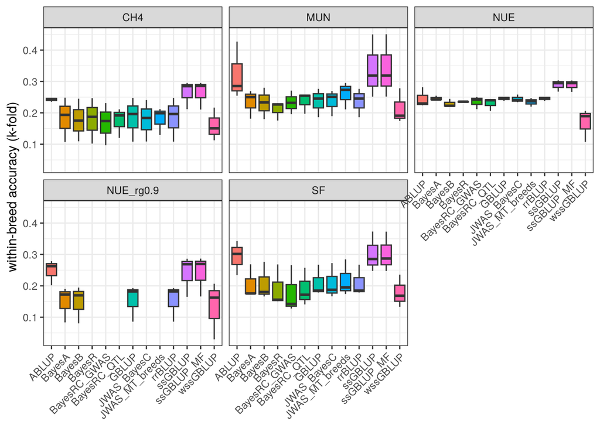

```r
ggplot(cv[scheme != "forward"], aes(model, acc_within_breed, fill = model)) +
  geom_boxplot(show.legend = FALSE) + facet_wrap(~trait) + theme_bw() +
  theme(axis.text.x = element_text(angle = 45, hjust = 1)) + labs(x = NULL, y = "within-breed accuracy (k-fold)")
```